# Analises Multinível - Laboratório (Parte 3)

Tiago Ferreira

Laboratório (Parte 2) | Breve introdução ao R:  
**1. Importar e Explorar a base de dados**  
**2. Regressão simples**  
**3. Regressão multi-nível**  
**3.1. Modelo Nulo e ICC**  
**3.2. Random Intercept Model com preditor de nível 1**  
**3.3. Os valores de p (significância)**  
**3.4. Random Intercept Model com preditores de nível 1 e 2**  
**3.5. Random Intercept Model com fatores de interação simples e multinível**  
**3.6. Random Intercept and slope Model**  
**4. Conclusão**

# Criar uma base de dados com estrutura multi-nível

O seguinte código serve apenas para demonstrar como foi criada a base de dados que será utilizada ao longo deste tutorial. Se desejar apenas importar a base de dados poderá simplesmente correr o código para importação de ficheiro csv que está disponível logo no início do ponto 1, *Importar e Explorar a base de dados*.

```r
set.seed(42) # para permitir reproduzir a mesma sequência de números aleatórios
nrich <- 40 # número de sujeitos  por escola ricas
npoor <- 160 # número de sujeitos  por escola pobres
# Parâmetros desejados
S.F.Rich <- -1 # parâmetros para número de amigos em escolas ricas
S.F.Poor <- 5 # parâmetros para número de amigos em escolas pobres

S.Q.Rich <- 1 # parâmetros para qualidade da escolas percecionada em escolas ricas
S.Q.Poor <- 7 # parâmetros para qualidade da escolas percecionada em escolas pobres

S.G.Rich <- 3 # parâmetros para GPA em escolas ricas
S.G.Poor <- .7 # parâmetros para GPA em escolas ricas

# Escolas ricas
# Escola 1
X1 <- rnorm(nrich, 10, 2) # número de amigos observados
Z1 <- runif(nrich, 1.0, 4.0) # GPA observado
H1 <- runif(nrich, 1.0, 7.0) # Qualidade da escola observada
Y1 <- S.F.Rich*X1 + S.G.Rich*Z1 + S.Q.Rich*H1 + 80 + rnorm(nrich, sd= 5) # Equação para definir valores observados de Happiness

# Escola 2
X2 <- rnorm(nrich, 10, 2) # número de amigos observados
Z2 <- runif(nrich, 1.0, 4.0) # GPA observado
H2 <- runif(nrich, 1.0, 7.0) # Qualidade da escola observada
Y2 <- S.F.Rich*X2 + S.G.Rich*Z2 + S.Q.Rich*H2 + 75 + rnorm(nrich, sd= 5) # Equação para definir valores observados de Happiness

# Escola 3
X3 <- rnorm(nrich, 10, 2) # número de amigos observados
Z3 <- runif(nrich, 1.0, 4.0) # GPA observado
H3 <- runif(nrich, 1.0, 7.0) # Qualidade da escola observada
Y3 <- S.F.Rich*X3 + S.G.Rich*Z3 + S.Q.Rich*H3 + 90 + rnorm(nrich, sd= 5) # Equação para definir valores observados de Happiness

# Escolas pobres
# Escola 4
X4 <- rnorm(npoor, 5, 2) # número de amigos observados
Z4 <- runif(npoor, 1.0, 4.0) # GPA observado
H4 <- runif(nrich, 1.0, 7.0) # Qualidade da escola observada
Y4 <- S.F.Poor*X4 + S.G.Poor*Z4 + S.Q.Poor*H4 + 35 + rnorm(npoor, sd = 10) # Equação para definir valores observados de Happiness

# Escola 5
X5 <- rnorm(npoor, 5, 2) # número de amigos observados
Z5 <- runif(npoor, 1.0, 4.0) # GPA observado
H5 <- runif(nrich, 1.0, 7.0) # Qualidade da escola observada
Y5 <- S.F.Poor*X5 + S.G.Poor*Z5 + S.Q.Poor*H5 + 40 + rnorm(npoor, sd = 10) # Equação para definir valores observados de Happiness

# Escola 6
X6 <- rnorm(npoor, 5, 2) # número de amigos observados
Z6 <- runif(npoor, 1.0, 4.0) # GPA observado
H6 <- runif(nrich, 1.0, 7.0) # Qualidade da escola observada
Y6 <- S.F.Poor*X6 + S.G.Poor*Z6 + S.Q.Poor*H6 + 50 + rnorm(npoor, sd = 10) # Equação para definir valores observados de Happiness

# As 3 escolas ricas:
Student.Data.School.1<-data.frame(Happiness=Y1, Friends=X1, Quality=H1, GPA=Z1)
Student.Data.School.2<-data.frame(Happiness=Y2, Friends=X2, Quality=H2, GPA=Z2)
Student.Data.School.3<-data.frame(Happiness=Y3, Friends=X3, Quality=H3, GPA=Z3)

# As 3 escolas pobres:
Student.Data.School.4<-data.frame(Happiness=Y4, Friends=X4, Quality=H4, GPA=Z4)
Student.Data.School.5<-data.frame(Happiness=Y5, Friends=X5, Quality=H5, GPA=Z5)
Student.Data.School.6<-data.frame(Happiness=Y6, Friends=X6, Quality=H6, GPA=Z6)

# Correlações within-group - escola 1
corr.student  <-  cor(Student.Data.School.1)
corrplot(corr.student, method = "number",diag = FALSE,type = "lower")

# Correlações within-group - escola 4
corr.student  <-  cor(Student.Data.School.4)
corrplot(corr.student, method = "number",diag = FALSE,type = "lower")

# Construir a base de dados final com os dados de todos as crianças de todas as escolas

All.Schools.Data <- rbind(Student.Data.School.1, Student.Data.School.2, Student.Data.School.3, Student.Data.School.4, Student.Data.School.5, Student.Data.School.6)
head(All.Schools.Data)

# Acrescentar uma variável identificadora do sujeito (StudentID)
All.Schools.Data$StudentID<-seq(1:nrow(All.Schools.Data))
head(All.Schools.Data)

# Acrescentar uma variável identificadora da escola (SchoolID)
All.Schools.Data$SchoolID<-c(rep(1, nrich), rep(2,nrich), rep(3, nrich), rep(4, npoor),
                             rep(5, npoor), rep(6, npoor))

# Criar um fator (SchoolContext) que identifique escolas nos dois tipos de contextos
All.Schools.Data$SchoolContext[All.Schools.Data$SchoolID>3] <- "poor neighborhood"
All.Schools.Data$SchoolContext[All.Schools.Data$SchoolID<4] <- "rich neighborhood"
All.Schools.Data$SchoolContext <- as.factor(All.Schools.Data$SchoolContext)

# Guarda base de dados em ficheiro csv (SchoolsData.csv)
write.csv(All.Schools.Data, "I:\\My Drive\\FPCEUP\\AtividadeDocente\\MultilevelReg\\MLReg_data\\SchoolsData.csv", row.names=FALSE)
```

# 1. Importar e Explorar a base de dados

Em vez de criar a base de dados do zero com o código anterior, poderá simplesmente importá-la do ficheiro csv disponibilizado no materiais de curso utilizando o código seguinte.

```r
library(data.table)  # se necessário: install.packages("data.table")
SchoolsData <- fread("I:\\My Drive\\FPCEUP\\AtividadeDocente\\MultilevelReg\\MLReg_data\\SchoolsData.csv")
```

A base de dados “SchoolsData” é composta por 600 alunos inseridos em 6 escolas, 3 em contextos economicamente favorecidos e 3 em contextos economicamente desfavorecidos. A variável em estudo é o nível de felicidade (“Happiness”) reportado por cada um dos alunos. Pretendemos explicar “Happiness” (variável dependente) em função do número de amigos (“Friends”), qualidade da escola percecionada por cada um dos alunos (“Quality”) e aproveito académico (“GPA”). Começamos por usar algumas funções já conhecidas para perceber a estrutura geral da base de dados.

```r
str(SchoolsData)
```

```
## Classes 'data.table' and 'data.frame':   600 obs. of  7 variables:
##  $ Happiness    : num  86.2 80.3 80.4 81.5 78.5 ...
##  $ Friends      : num  12.74 8.87 10.73 11.27 10.81 ...
##  $ Quality      : num  3.14 3.46 4.44 4.54 5.32 ...
##  $ GPA          : num  2.74 1.47 2.08 2.94 3.33 ...
##  $ StudentID    : int  1 2 3 4 5 6 7 8 9 10 ...
##  $ SchoolID     : int  1 1 1 1 1 1 1 1 1 1 ...
##  $ SchoolContext: chr  "rich neighborhood" "rich neighborhood" "rich neighborhood" "rich neighborhood" ...
##  - attr(*, ".internal.selfref")=<externalptr>
```

```r
names(SchoolsData)
```

```
## [1] "Happiness"     "Friends"       "Quality"       "GPA"
## [5] "StudentID"     "SchoolID"      "SchoolContext"
```

```r
summary(SchoolsData)
```

```
##    Happiness         Friends           Quality           GPA
##  Min.   : 43.79   Min.   :-0.9176   Min.   :1.028   Min.   :1.001
##  1st Qu.: 79.86   1st Qu.: 4.1337   1st Qu.:2.538   1st Qu.:1.724
##  Median : 92.74   Median : 5.4336   Median :4.282   Median :2.517
##  Mean   : 94.10   Mean   : 5.9622   Mean   :4.131   Mean   :2.497
##  3rd Qu.:106.52   3rd Qu.: 7.6570   3rd Qu.:5.618   3rd Qu.:3.274
##  Max.   :151.61   Max.   :14.5733   Max.   :6.952   Max.   :3.999
##    StudentID        SchoolID   SchoolContext
##  Min.   :  1.0   Min.   :1.0   Length:600
##  1st Qu.:150.8   1st Qu.:4.0   Class :character
##  Median :300.5   Median :5.0   Mode  :character
##  Mean   :300.5   Mean   :4.4
##  3rd Qu.:450.2   3rd Qu.:6.0
##  Max.   :600.0   Max.   :6.0
```

```r
SchoolsData$SchoolContext <- as.factor(SchoolsData$SchoolContext) # transformar a variável "SchoolContext" num fator
sapply(SchoolsData, class) # verificar a classe de todas as variáveis de SchoolsData
```

```
##     Happiness       Friends       Quality           GPA     StudentID
##     "numeric"     "numeric"     "numeric"     "numeric"     "integer"
##      SchoolID SchoolContext
##     "integer"      "factor"
```

Exploramos agora graficamente a base de dados. As escolas 1, 2 e 3 estão situadas em contextos economicamente mais favorecidos, enquanto as escolas 4, 5 e 6 em contexto menos favorecidos. Usamos para o efeito o pacote ggplot2.

```r
library(ggplot2) # se necessário install.packages("ggplot2")
table(SchoolsData$SchoolID, SchoolsData$SchoolContext)
```

```
##
##     poor neighborhood rich neighborhood
##   1                 0                40
##   2                 0                40
##   3                 0                40
##   4               160                 0
##   5               160                 0
##   6               160                 0
```

Começamos por criar um gráfico para verificar a relação entre os scores de felicidade do alunos (“Happiness” - VD) e número de amigos (“Friends”, VI).

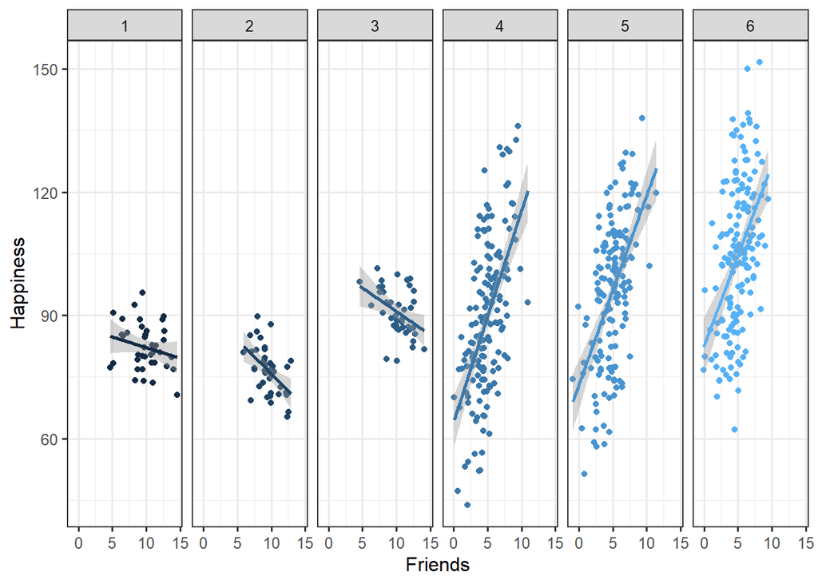

```r
theme_set(theme_bw(base_size = 12, base_family = "")) # este código não é essencial e apenas serve para definir um tema comum aos gráficos criados posteriormente

Model.Plot.Friends <-ggplot(data = SchoolsData, aes(x = Friends, y=Happiness, group=SchoolID))+
  facet_grid( ~ SchoolID)+
  geom_point(aes(colour = SchoolID))+
  geom_smooth(method = "lm", se = TRUE, aes(colour = SchoolID))+
  xlab("Friends")+ylab("Happiness")+
  theme(legend.position = "none")
Model.Plot.Friends
```

Tal como esperado, os efeitos entre as duas variáveis, “Happiness” e “Friends”, parecem variar de acordo com as escolas onde são avaliados. Visualizamos de seguida a relação entre qualidade da escola percecionada por cada um dos alunos (“Quality” - VI) e scores de felicidade (“Happiness” – VD).

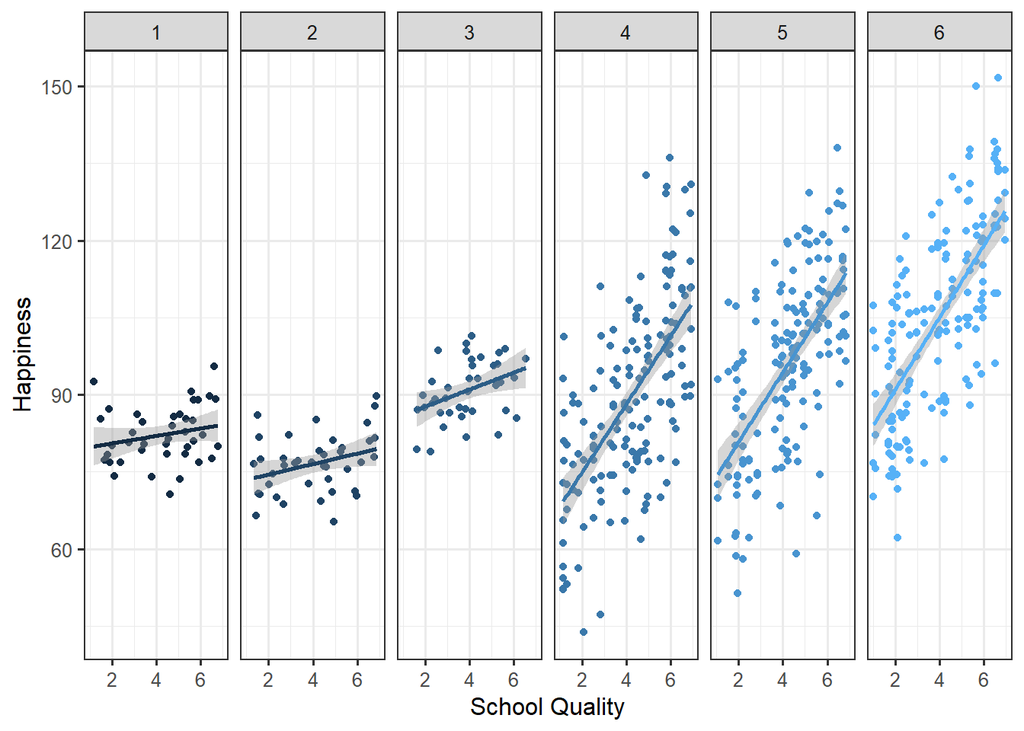

```r
Model.Plot.Quality <-ggplot(data = SchoolsData, aes(x =Quality, y=Happiness,group=SchoolID))+
  facet_grid( ~ SchoolID)+
  geom_point(aes(colour = SchoolID))+
  geom_smooth(method = "lm", se = TRUE, aes(colour = SchoolID))+
  xlab("School Quality")+ylab("Happiness")+
  theme(legend.position = "none")
Model.Plot.Quality
```

Pelo gráfico anterior percebemos que, embora pareça existe um efeito positivo entre as duas variáveis, no entanto, esses efeitos são mais evidentes nas escolas inseridas em contextos desfavorecidos (escolas nr. 4, 5 e 6).  
Finalmente, verificamos a relação entre o desempenho académico (“GPA” - VI) e scores de felicidade (“Happiness” – VD).

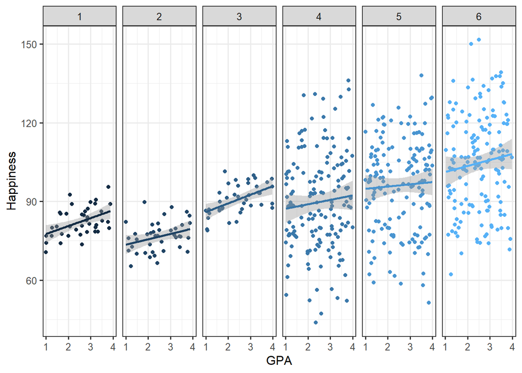

```r
Model.Plot.GPA <-ggplot(data = SchoolsData, aes(x =GPA, y=Happiness,group=SchoolID))+
  facet_grid( ~ SchoolID)+
  geom_point(aes(colour = SchoolID))+
  geom_smooth(method = "lm", se = TRUE, aes(colour = SchoolID))+
  xlab("GPA")+ylab("Happiness")+
  theme(legend.position = "none")
Model.Plot.GPA
```

Aqui, a relação (slope) entre as duas variáveis é semelhante nos dois tipos de escolas, embora pareçam existir diferenças nos intercepts dessas slopes (i.e., níveis médios de felicidade quando o valor de GPA é 0).  
Analisamos agora as correlações entre as diferentes variáveis para a amostra completa, incluindo crianças em escolas de contexto favorecidos e desfavorecidos.

```r
names(SchoolsData)
```

```
## [1] "Happiness"     "Friends"       "Quality"       "GPA"
## [5] "StudentID"     "SchoolID"      "SchoolContext"
```

```r
corr.student  <-  cor(SchoolsData[,1:4])
corr.student
```

```
##            Happiness      Friends     Quality         GPA
## Happiness 1.00000000  0.081075328  0.51237207 0.089540544
## Friends   0.08107533  1.000000000 -0.02175377 0.002469865
## Quality   0.51237207 -0.021753770  1.00000000 0.020583165
## GPA       0.08954054  0.002469865  0.02058316 1.000000000
```

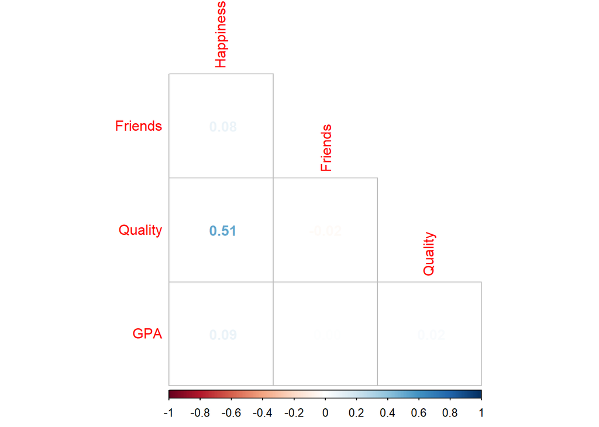

```r
library(corrplot) # se necessário install.pachages("corrplot")
corrplot(corr.student, method = "number", diag = FALSE, type = "lower")
```

```r
?corrplot
```

```
## starting httpd help server ... done
```

Olhemos para as mesmas correlações, separadamente para os dois tipos de escolas na amostra.

- Para escolas em contextos favorecidos…

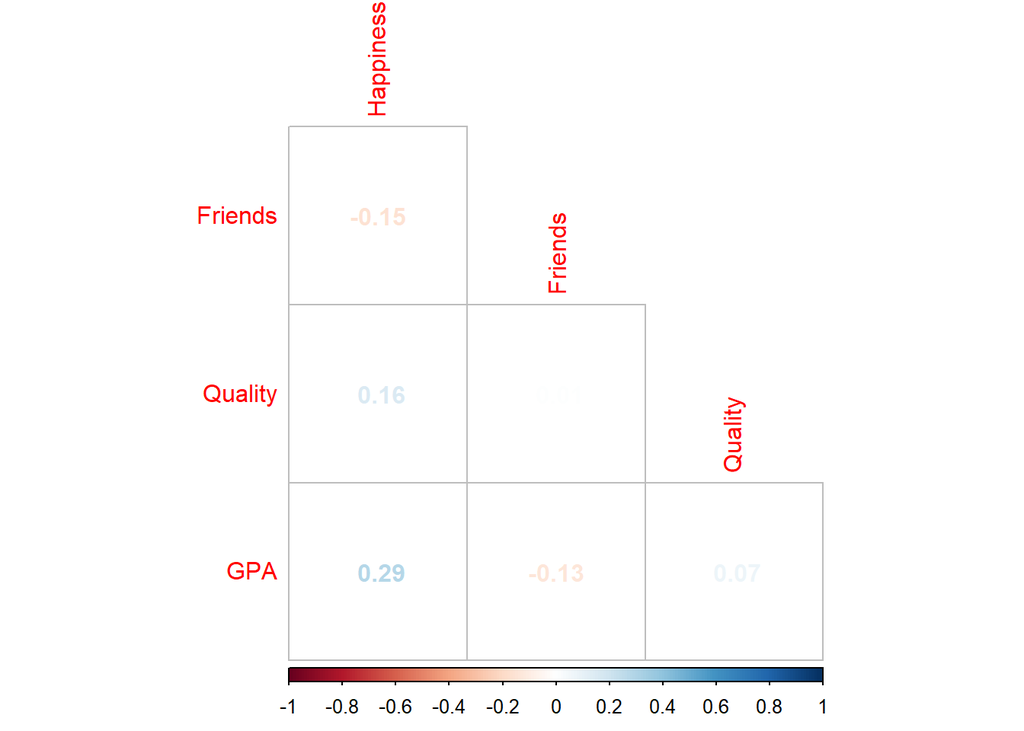

```r
SchoolsData_rich <- subset(SchoolsData, SchoolContext=="rich neighborhood")
corr.student_rich  <-  cor(SchoolsData_rich[,1:4])
corrplot(corr.student_rich, method = "number", diag = FALSE, type = "lower")
```

- Para escolas em contextos desfavorecidos…

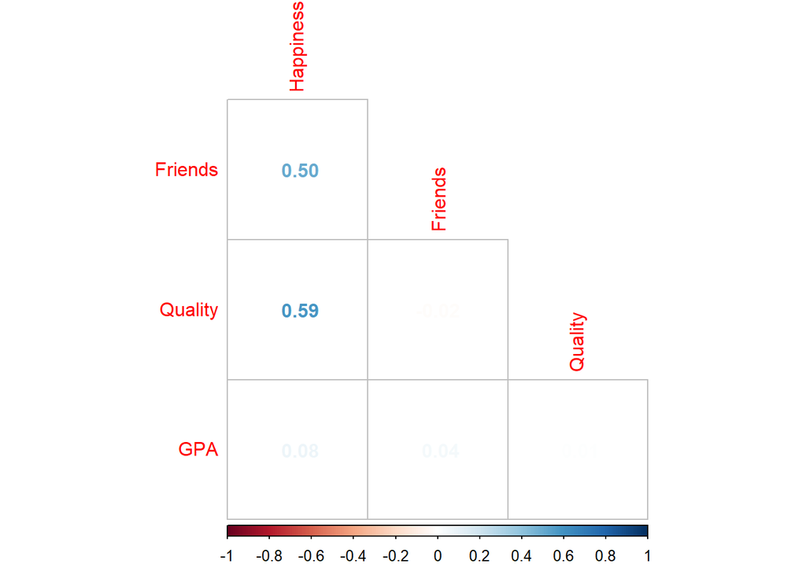

```r
SchoolsData_poor <- subset(SchoolsData, SchoolContext=="poor neighborhood")
corr.student_poor  <-  cor(SchoolsData_poor [,1:4])
corrplot(corr.student_poor, method = "number", diag = FALSE, type = "lower")
```

É de notar que o padrão de correlações parece mudar entre os dois grupos de escolas, sendo diferente do padrão de correlações observado para a amostra total. Estes resultados sugerem a presença de relações diferentes entre as variáveis observadas em função do tipo de escola considerado.

# 2. Regressão simples

De seguida, testamos um modelo de regressão simples. Esta abordagem analítica não considera o facto dos dados estarem organizados de forma hierárquica, isto é não tem em conta o facto dos estudantes na amostra partilharem as mesmas escolas. Para facilitar a interpretação dos dados, vamos começar por centrar as variáveis à “grand mean”. Para isso, subtraímos a média de uma determinada variável ao valores individuais observados para cada um dos sujeitos nessa mesma variável. Conseguimos facilmente fazer isto através da função “scale()” com o argumento scale = FALSE.

```r
# ?scale
SchoolsData$Friends.C <- scale(SchoolsData$Friends, scale = FALSE)[,]

# Na prática, o resultado é obtido através do seguinte código:
# SchoolsData$Friends.C <- SchoolsData$Friends - mean(SchoolsData$Friends)

SchoolsData$Quality.C <- scale(SchoolsData$Quality, scale = FALSE)[,]
SchoolsData$GPA.C <- scale(SchoolsData$GPA, scale = FALSE)[,]
```

Testamos agora o nosso modelo de regressão simples, usando as variáveis centradas à média, o que implica que ao valor observado de zero corresponde a média da amostra.

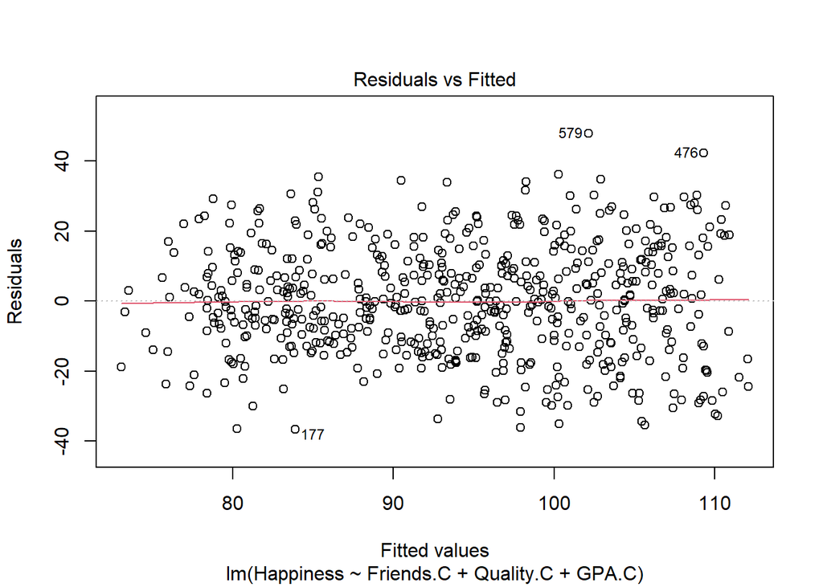

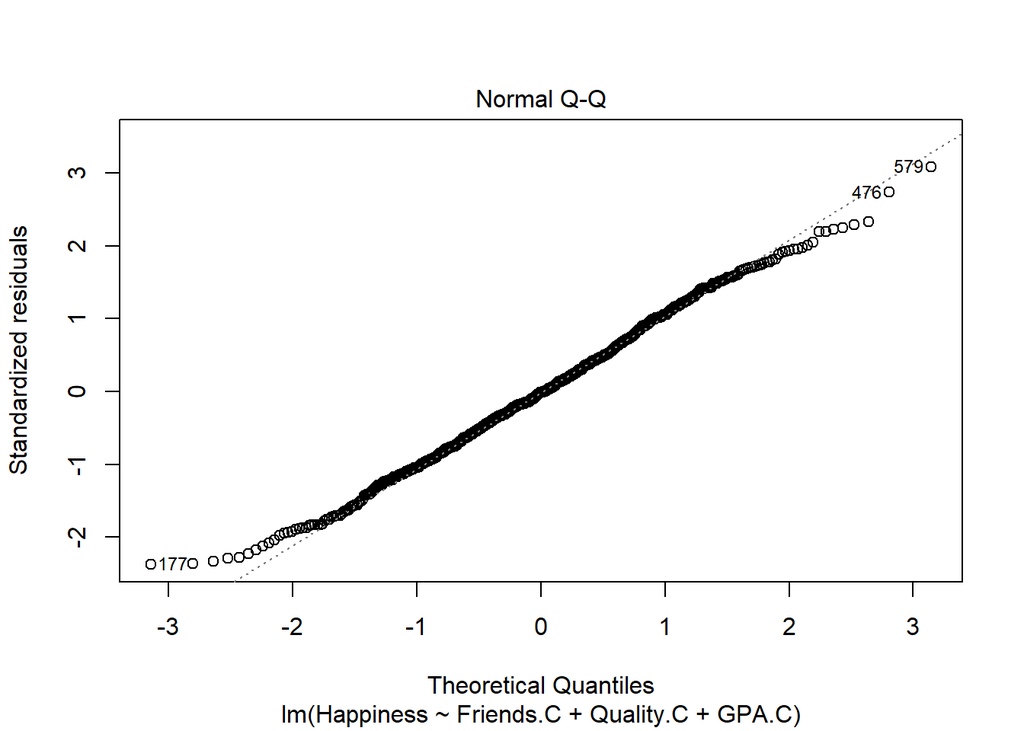

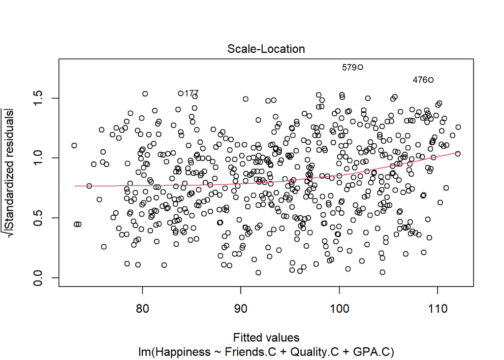

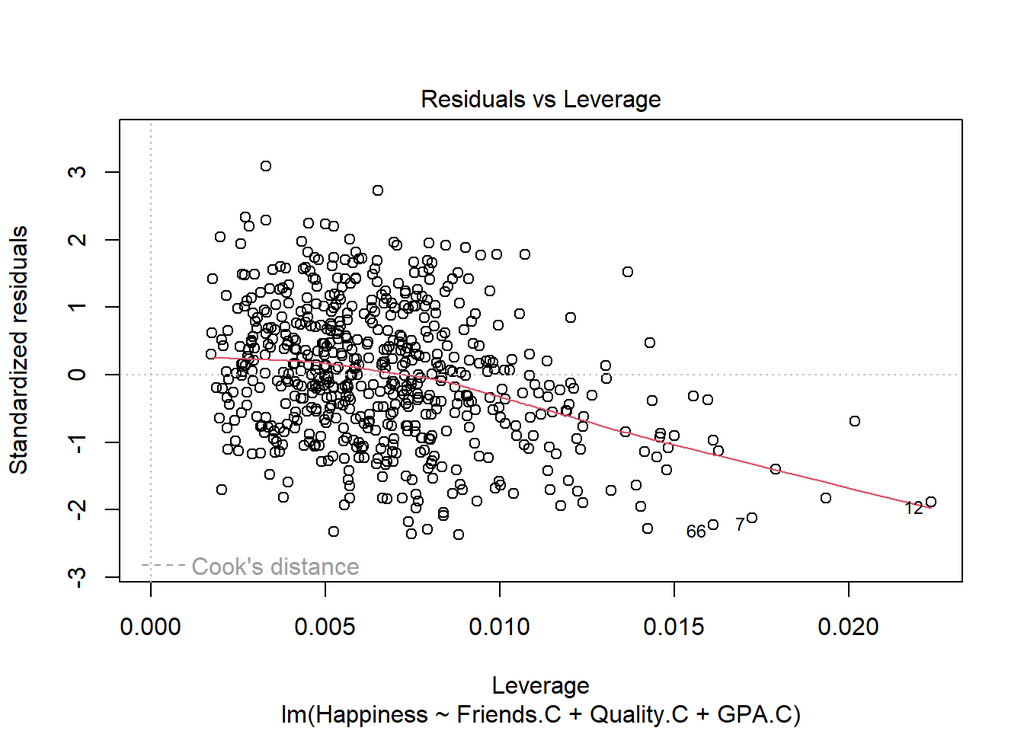

```r
Reg.Model <- lm(Happiness ~ Friends.C + Quality.C + GPA.C, data = SchoolsData)
plot(Reg.Model) # podemos avaliar visualmente a qualidade do modelo de regressão
```

```r
summary(Reg.Model)
```

```
##
## Call:
## lm(formula = Happiness ~ Friends.C + Quality.C + GPA.C, data = SchoolsData)
##
## Residuals:
##    Min     1Q Median     3Q    Max
## -36.67 -11.16  -0.19  10.73  47.84
##
## Coefficients:
##             Estimate Std. Error t value Pr(>|t|)
## (Intercept)  94.0998     0.6337 148.481  < 2e-16 ***
## Friends.C     0.5962     0.2256   2.642  0.00845 **
## Quality.C     5.5238     0.3753  14.718  < 2e-16 ***
## GPA.C         1.6132     0.7134   2.261  0.02411 *
## ---
## Signif. codes:  0 '***' 0.001 '**' 0.01 '*' 0.05 '.' 0.1 ' ' 1
##
## Residual standard error: 15.52 on 596 degrees of freedom
## Multiple R-squared:  0.2772, Adjusted R-squared:  0.2736
## F-statistic:  76.2 on 3 and 596 DF,  p-value: < 2.2e-16
```

Considerando a amostra na sua totalidade, o sumário do modelo de regressão simples indica a presença de efeitos significativos do número de amigos (b = 0.60, p < .01), qualidade da escola (b = 5.52, p < .01), e GPA (b = 1.61, p < .05) sobre a nossa variável dependente (“Happiness”). Mas será que este padrão de resultados se repete quando analisamos os dados separadamente para as escolas nos diferentes tipos de contextos (i.e., contextos favorecidos e desfavorecidos).

- Regressão simples para escolas favorecidas  
  A função subset () permite selecionar os casos pretendidos, neste caso apenas serão consideradas as crianças em escolas favorecidas (?subset)

```r
Reg.Model_rich <- lm(Happiness ~ Friends.C + Quality.C + GPA.C,
                     data = subset(SchoolsData, SchoolContext=="rich neighborhood"))
summary(Reg.Model_rich)
```

```
##
## Call:
## lm(formula = Happiness ~ Friends.C + Quality.C + GPA.C, data = subset(SchoolsData,
##     SchoolContext == "rich neighborhood"))
##
## Residuals:
##      Min       1Q   Median       3Q      Max
## -14.9806  -6.3417  -0.3278   5.8251  18.6317
##
## Coefficients:
##             Estimate Std. Error t value Pr(>|t|)
## (Intercept)  85.0221     1.5076  56.395  < 2e-16 ***
## Friends.C    -0.4583     0.3414  -1.342  0.18206
## Quality.C     0.7058     0.4387   1.609  0.11033
## GPA.C         2.4555     0.8278   2.966  0.00366 **
## ---
## Signif. codes:  0 '***' 0.001 '**' 0.01 '*' 0.05 '.' 0.1 ' ' 1
##
## Residual standard error: 7.75 on 116 degrees of freedom
## Multiple R-squared:  0.1155, Adjusted R-squared:  0.09259
## F-statistic: 5.048 on 3 and 116 DF,  p-value: 0.002532
```

Verificamos que dois dos três efeitos deixam de ser significativos, restando apenas o efeito significativo de “GPA” sobre “Happiness”. De notar que o efeito do número de amigos no nível de felicidade muda até de sinal, passando a ser negativo (embora não significativo).

- Regressão simples para escolas desfavorecidas

```r
Reg.Model_poor <- lm(Happiness ~ Friends.C + Quality.C + GPA.C,
                     data = subset(SchoolsData, SchoolContext=="poor neighborhood"))
summary(Reg.Model_poor)
```

```
##
## Call:
## lm(formula = Happiness ~ Friends.C + Quality.C + GPA.C, data = subset(SchoolsData,
##     SchoolContext == "poor neighborhood"))
##
## Residuals:
##     Min      1Q  Median      3Q     Max
## -36.632  -8.796  -0.075   8.036  36.787
##
## Coefficients:
##             Estimate Std. Error t value Pr(>|t|)
## (Intercept) 101.4449     0.6054 167.568   <2e-16 ***
## Friends.C     4.8386     0.2717  17.807   <2e-16 ***
## Quality.C     6.6096     0.3191  20.716   <2e-16 ***
## GPA.C         1.0653     0.6091   1.749    0.081 .
## ---
## Signif. codes:  0 '***' 0.001 '**' 0.01 '*' 0.05 '.' 0.1 ' ' 1
##
## Residual standard error: 11.93 on 476 degrees of freedom
## Multiple R-squared:  0.6085, Adjusted R-squared:  0.6061
## F-statistic: 246.6 on 3 and 476 DF,  p-value: < 2.2e-16
```

No caso das crianças em contexto escolares desfavorecidos, o efeito do GPA no nível de felicidade não é significativo, mantendo-se os efeitos significativos do número de amigos e qualidade da escola sobre a variável dependente (i.e., happiness).  
Em síntese, os resultados anteriores não parecem refletir de forma exata o que se passa em cada uma das escolas. A regressão simples, aplicada à totalidade da amostra, indica que todas as variáveis independentes (VI) têm um efeito significativo sobre a variável dependente (VD) quando isso não é verdade para os dois grupos de escolas. Trata-se de um exemplo em que os resultados da regressão simples, por não considerar as estrutura aninhada ou hierárquica dos dados, pode conduzir a conclusões erradas acerca das relação entre variáveis.  
Salientamos que este exemplo é meramente académico. Porque os dados foram simulados, sabíamos previamente que o padrão de associações entre variáveis estaria dependente do contexto económico da escola. Na realidade, o investigador poderá não ter acesso a essa informação quanto está a realizar as suas análises. Caso essa informação esteja disponível poderá facilmente considerá-la no modelo como um predito de nível 2 (i.e., escola). É ainda importante considerar que este exemplo apenas usa 6 escolas e que em situações “normais” o número de escolas é substancialmente maior, não sendo realista tratar o contexto económico como um fator fixo, controlado ao nível do design do estudo.  
Uma forma alternativa de abordar este tipo de problemas metodológicos é através da implementação de modelos de regressão multi-nível. Este tipo de modelos permite aos investigadores distinguirem entre efeitos dentro (“within-group”) e entre grupos (“between-group”), enquanto os modelos simples de regressão combinam este dois tipos de efeitos num coeficiente único (fixo) de regressão.

# 3. Regressão multi-nível

## 3.1. Modelo Nulo e ICC

Quando resolvemos testar um modelo multi-nível é geralmente boa ideia perceber primeiro se, face aos nosso dados, será realmente necessário ter este tipo de abordagem analítica. Para percebermos essa necessidade, devemos testar o modelo multi-nível mais simples, chamado frequentemente de modelo nulo, e que avalia o efeito médio do contexto sobre a nossa VD, neste caso “Happiness”. O modelo nulo não tem VI’s, sendo apenas útil para obter uma estimativa das variâncias residuais e dos intercepts, quando apenas o efeito da escola é considerado. O modelo é representado pela seguinte equação:

yij = *β*0 + *U*0j + *ε*ij  
**Fixed effects:**  
*β*0 - intercept do modelo  
**Random effects:**  
*U*0j - variância do grupo para o intercept  
*ε*ij - variância individual

Para analisar modelos multi-nível no R recorremos ao pacote lme4.

```r
library(lme4) # se necessário: install.packages("lme4")
head(SchoolsData)
```

```
##    Happiness   Friends  Quality      GPA StudentID SchoolID     SchoolContext
## 1:  86.19639 12.741917 3.140332 2.744812         1        1 rich neighborhood
## 2:  80.30396  8.870604 3.463811 1.473716         2        1 rich neighborhood
## 3:  80.38805 10.726257 4.440855 2.077085         3        1 rich neighborhood
## 4:  81.47855 11.265725 4.538070 2.936896         4        1 rich neighborhood
## 5:  78.52017 10.808537 5.317944 3.327470         5        1 rich neighborhood
## 6:  84.71489  9.787751 3.369838 2.690941         6        1 rich neighborhood
##    Friends.C  Quality.C      GPA.C
## 1:  6.779751 -0.9906700  0.2478625
## 2:  2.908438 -0.6671913 -1.0232338
## 3:  4.764091  0.3098534 -0.4198646
## 4:  5.303559  0.4070678  0.4399462
## 5:  4.846371  1.1869417  0.8305206
## 6:  3.825585 -0.7611637  0.1939911
```

```r
?lmer

Null <- lmer(Happiness ~ 1 # define “Happinesss” em função do intercept (fixed effect)
             + (1|SchoolID), # e que cada escola tem o seu intercept (random effect)
             data=SchoolsData) # base de dados
```

```r
summary(Null)
```

```
## Linear mixed model fit by REML ['lmerMod']
## Formula: Happiness ~ 1 + (1 | SchoolID)
##    Data: SchoolsData
##
## REML criterion at convergence: 5070.4
##
## Scaled residuals:
##      Min       1Q   Median       3Q      Max
## -2.80824 -0.61011 -0.00664  0.59575  2.88781
##
## Random effects:
##  Groups   Name        Variance Std.Dev.
##  SchoolID (Intercept)  94.7     9.731
##  Residual             267.3    16.348
## Number of obs: 600, groups:  SchoolID, 6
##
## Fixed effects:
##             Estimate Std. Error t value
## (Intercept)   90.179      4.058   22.22
```

O sumário do modelo nulo não é muito informativo, no entanto permite clarificar as duas componentes de variância, entre clusters (τ2) e indivíduos (σ2). Estes valores surgem no modelo na parte dedicada aos random effects. Neste caso τ2 = 94.7, enquanto que σ2 = 267.3. Podemos usar estes valores para calcular o Inter-Class Correlation (ICC), de forma a clarificar a necessidade de uma abordagem analítica multi-nível. O ICC permite avaliar o efeito do cluster nos nossos dados de Happiness, sendo uma medida da quantidade de variância da VD explicada pelo nível 2 do nosso modelo (escola). Podemos também interpretar o ICC como a correlação média nos scores de happiness observada entre estudantes da mesma escola. Um valor de ICC diferente de 0 justifica a adoção de modelos multi-nível.  
Podemos calcular o ICC de várias formas. A função VarCorr() permite extrair as componentes de variância estimadas pelo modelo.

```r
?VarCorr
vc <- VarCorr(Null)
```

Utilizamos a função print() para visualizar essas componentes de variância, no entanto, por defeito, esta função apenas extrai os valores de desvio padrão.

```r
print(vc)
```

```
##  Groups   Name        Std.Dev.
##  SchoolID (Intercept)  9.7314
##  Residual             16.3482
```

Assim, devemos especificar através do argumento “comp”, que queremos também que o R nos mostre as variâncias.

```r
print(vc, comp=c("Variance", "Std.Dev"))
```

```
##  Groups   Name        Variance Std.Dev.
##  SchoolID (Intercept)  94.701   9.7314
##  Residual             267.263  16.3482
```

Criamos agora um objeto de dados apenas com as variâncias para o nosso modelo.

```r
vc <- print(vc, comp=c("Variance", "Std.Dev"))
```

```
##  Groups   Name        Variance Std.Dev.
##  SchoolID (Intercept)  94.701   9.7314
##  Residual             267.263  16.3482
```

```r
vc <- as.data.frame(vc)[,c("grp", "vcov")]
```

Com estes dados, podemos agora calcular facilmente o ICC = var. group / var. total, sendo que a var. total = var. grupo + var. indivíduos.

```r
vc[1,2]
```

```
## [1] 94.70073
```

```r
vc[,2]
```

```
## [1]  94.70073 267.26342
```

```r
ICC <- vc[1,2]/sum(vc[,2])
ICC
```

```
## [1] 0.2616301
```

```r
ICC_user <- function(nome.modelo) {
  vc <- VarCorr(nome.modelo)
  vc <- print(vc, comp=c("Variance", "Std.Dev"))
  vc <- as.data.frame(vc)[,c("grp", "vcov")]
  ICC <- vc[1,2]/sum(vc[,2])
  return(c(ICC = ICC))
}
```

Assim, apenas temos que especificar o nome do modelo nulo como argumento e a função ICC_user faz o resto.

```r
ICC_user(Null)
```

```
##  Groups   Name        Variance Std.Dev.
##  SchoolID (Intercept)  94.701   9.7314
##  Residual             267.263  16.3482
```

```
##       ICC
## 0.2616301
```

Para simplificar ainda um pouco mais a nossa vida, podemos usar uma função pré-existente, embora isso obrigue à instalação de um novo pacote no R. Neste caso, usamos a função icc() do pacote performance

```r
# se necesssário, install.packages("performance")
library(performance)
icc(Null)
```

```
## # Intraclass Correlation Coefficient
##
##     Adjusted ICC: 0.262
##   Unadjusted ICC: 0.262
```

```r
# ?icc
```